# COVID-19 Case Data

G. E.

## Introduction

John Hopkins University (JHU) Center for Systems Science and Engineering (CSSE) Last Updated: March 10, 2023

This document analyzes COVID mortality.

> **Dataset Description**: This is the data repository for the 2019 Novel Coronavirus Visual Dashboard operated by the Johns Hopkins University Center for Systems Science and Engineering (JHU CSSE). Also, Supported by ESRI Living Atlas Team and the Johns Hopkins University Applied Physics Lab (JHU APL).

## Setup the R Environment

To setup the R environment, libraries `lubridate` and `tidyverse` were imported.

## Import the Data

The dataset was imported via URL, made publicly available on Github by the JHU CSSE.

Dataset URL: “https://raw.githubusercontent.com/CSSEGISandData/COVID-19/master/csse_covid_19_data/csse_covid_19_time_series/”

```r
url_in <- "https://raw.githubusercontent.com/CSSEGISandData/COVID-19/master/csse_covid_19_data/csse_covid_19_time_series/" # nolint: line_length_linter.
file_names <- c("time_series_covid19_confirmed_global.csv",
                "time_series_covid19_deaths_global.csv",
                "time_series_covid19_confirmed_US.csv",
                "time_series_covid19_deaths_US.csv")
urls <- str_c(url_in, file_names) # string concatenate
global_cases <- read_csv(urls[1])
global_deaths <- read_csv(urls[2])
us_cases <- read_csv(urls[3])
us_deaths <- read_csv(urls[4])
uid_lookup_url <- "https://raw.githubusercontent.com/CSSEGISandData/COVID-19/refs/heads/master/csse_covid_19_data/UID_ISO_FIPS_LookUp_Table.csv" # nolint: line_length_linter.
uid <- read_csv(uid_lookup_url) %>% # uid lookup
  select(-c(Lat, Long_, Combined_Key, code3, iso2, iso3, Admin2))
```

## Data Cleaning

```r
global_cases <- global_cases %>% # global cases
  pivot_longer(cols = -c("Province/State",
                         "Country/Region", Lat, Long),
               names_to = "date",
               values_to = "cases") %>%
  select(-c(Lat, Long))
global_deaths <- global_deaths %>% # global deaths
  pivot_longer(cols = -c("Province/State",
                         "Country/Region", Lat, Long),
               names_to = "date",
               values_to = "deaths") %>%
  select(-c(Lat, Long))
global <- global_cases %>% # global all
  full_join(global_deaths) %>%
  rename(Country_Region = "Country/Region",
         Province_State = "Province/State") %>%
  mutate(date = mdy(date))
global <- global %>% filter(cases > 0)
global <- global %>%
  unite("Combined_Key",
        c(Province_State, Country_Region),
        sep = ", ",
        na.rm = TRUE,
        remove = FALSE)
global <- global %>%
  left_join(uid, by = c("Province_State", "Country_Region")) %>%
  select(-c(UID, FIPS)) %>%
  select(Province_State, Country_Region, date,
         cases, deaths, Population,
         Combined_Key)
us_cases %>% # us cases
  pivot_longer(cols = -(UID:Combined_Key),
               names_to = "date",
               values_to = "cases")
```

```
## # A tibble: 3,819,906 × 13
##         UID iso2  iso3  code3  FIPS Admin2  Province_State Country_Region   Lat
##       <dbl> <chr> <chr> <dbl> <dbl> <chr>   <chr>          <chr>          <dbl>
##  1 84001001 US    USA     840  1001 Autauga Alabama        US              32.5
##  2 84001001 US    USA     840  1001 Autauga Alabama        US              32.5
##  3 84001001 US    USA     840  1001 Autauga Alabama        US              32.5
##  4 84001001 US    USA     840  1001 Autauga Alabama        US              32.5
##  5 84001001 US    USA     840  1001 Autauga Alabama        US              32.5
##  6 84001001 US    USA     840  1001 Autauga Alabama        US              32.5
##  7 84001001 US    USA     840  1001 Autauga Alabama        US              32.5
##  8 84001001 US    USA     840  1001 Autauga Alabama        US              32.5
##  9 84001001 US    USA     840  1001 Autauga Alabama        US              32.5
## 10 84001001 US    USA     840  1001 Autauga Alabama        US              32.5
## # ℹ 3,819,896 more rows
## # ℹ 4 more variables: Long_ <dbl>, Combined_Key <chr>, date <chr>, cases <dbl>
```

```r
us_cases <- us_cases %>%
  pivot_longer(cols = -(UID:Combined_Key),
               names_to = "date",
               values_to = "cases") %>%
  select(Admin2:cases) %>%
  mutate(date = mdy(date)) %>%
  select(-c(Lat, Long_))
us_deaths <- us_deaths %>% # us deaths
  pivot_longer(cols = -(UID:Population),
               names_to = "date",
               values_to = "deaths") %>%
  select(Admin2:deaths) %>%
  mutate(date = mdy(date)) %>%
  select(-c(Lat, Long_))
us <- us_cases %>% # us all
  full_join(us_deaths)
```

## Visualize and Analyze

### Visualizations

```r
us_by_state <- us %>% # us state
  group_by(Province_State, Country_Region, date) %>%
  summarize(cases = sum(cases), deaths = sum(deaths),
            Population = sum(Population)) %>%
  mutate(deaths_per_mill = deaths * 1000000 / Population) %>%
  select(Province_State, Country_Region, date, cases, deaths, deaths_per_mill,
         Population) %>%
  ungroup()
us_totals <- us_by_state %>% # us totals
  group_by(Country_Region, date) %>%
  summarise(cases = sum(cases), deaths = sum(deaths),
            Population = sum(Population)) %>%
  mutate(deaths_per_mill = deaths * 1000000 / Population) %>%
  select(Country_Region, date,
         cases, deaths, deaths_per_mill, Population) %>%
  ungroup()
```

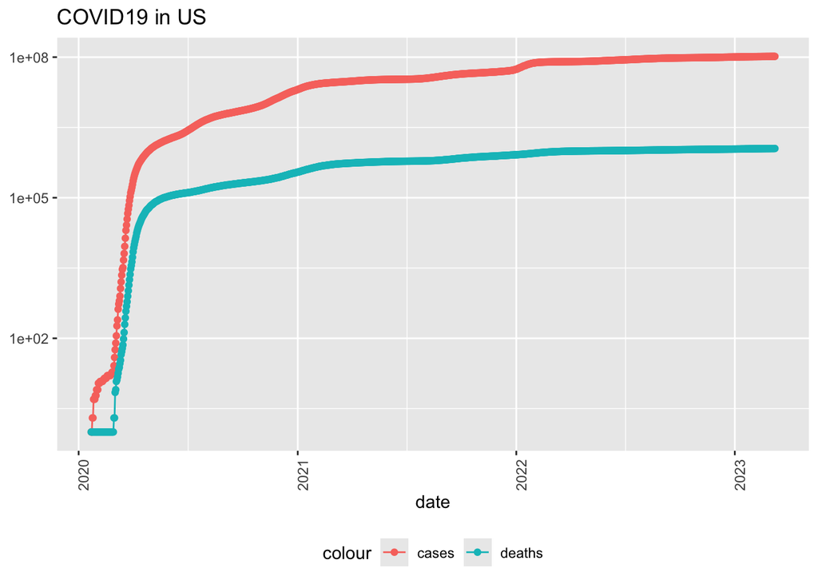

```r
us_totals %>% # line graph of us totals
  filter(cases > 0) %>%
  ggplot(aes(x = date, y = cases)) +
  geom_line(aes(color = "cases")) +
  geom_point(aes(color = "cases")) +
  geom_line(aes(y = deaths, color = "deaths")) +
  geom_point(aes(y = deaths, color = "deaths")) +
  scale_y_log10() +
  theme(legend.position = "bottom",
        axis.text.x = element_text(angle = 90)) +
  labs(title = "COVID19 in US", y = NULL)
```

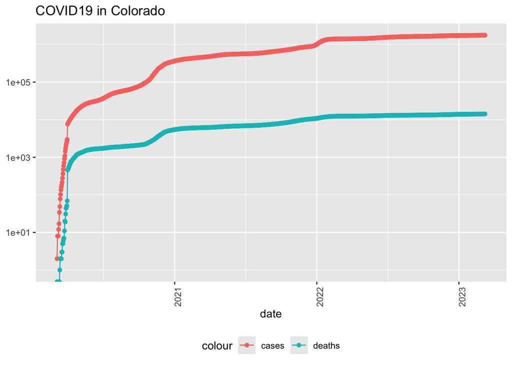

```r
state <- "Colorado"
colo <- us_by_state %>%
  filter(Province_State == state) %>%
  filter(cases > 0)
colo %>%
  ggplot(aes(x = date, y = cases)) +
  geom_line(aes(color = "cases")) +
  geom_point(aes(color = "cases")) +
  geom_line(aes(y = deaths, color = "deaths")) +
  geom_point(aes(y = deaths, color = "deaths")) +
  scale_y_log10() +
  theme(legend.position = "bottom",
        axis.text.x = element_text(angle = 90)) +
  labs(title = str_c("COVID19 in ", state), y = NULL)
```

### Analysis

[figure not shown]

```r
us_by_state <- us_by_state %>%
  mutate(new_cases = cases - lag(cases),
         new_deaths = deaths - lag(deaths))
us_totals <- us_totals %>%
  mutate(new_cases = cases - lag(cases),
         new_deaths = deaths - lag(deaths))
us_by_state %>%
  filter(Province_State == state) %>%
  ggplot(aes(x = date, y = new_cases)) +
  geom_line(aes(color = "new_cases")) +
  geom_point(aes(color = "new_cases")) +
  geom_line(aes(y = new_deaths, color = "new_deaths")) +
  geom_point(aes(y = new_deaths, color = "new_deaths")) +
  scale_y_log10() +
  theme(legend.position = "bottom",
        axis.text.x = element_text(angle = 90)) +
  labs(title = "COVID19 in US", y = NULL)
```

[figure not shown]

```r
colo <- colo %>%
  mutate(YEAR = year(date))
colo %>%
  count(YEAR) %>%
  mutate(pct_change = (n - lag(n)) / lag(n) * 100) %>%
  ggplot(aes(x = YEAR, y = pct_change)) +
  geom_line() +
  geom_point() +
  theme(legend.position = "bottom",
        axis.text.x = element_text(angle=90)) +
  labs(title = "Percentage Change in Annual Cases", y = NULL)
```

## Modeling

```r
mod <- lm(deaths ~ cases, data = colo)
colo %>% mutate(pred = predict(mod))
```

```
## # A tibble: 1,100 × 9
##    Province_State Country_Region date       cases deaths deaths_per_mill
##    <chr>          <chr>          <date>     <dbl>  <dbl>           <dbl>
##  1 Colorado       US             2020-03-05     2      0           0
##  2 Colorado       US             2020-03-06     8      0           0
##  3 Colorado       US             2020-03-07     8      0           0
##  4 Colorado       US             2020-03-08     8      0           0
##  5 Colorado       US             2020-03-09    12      0           0
##  6 Colorado       US             2020-03-10    17      0           0
##  7 Colorado       US             2020-03-11    34      0           0
##  8 Colorado       US             2020-03-12    49      1           0.174
##  9 Colorado       US             2020-03-13    78      2           0.347
## 10 Colorado       US             2020-03-14   103      2           0.347
## # ℹ 1,090 more rows
## # ℹ 3 more variables: Population <dbl>, YEAR <dbl>, pred <dbl>
```

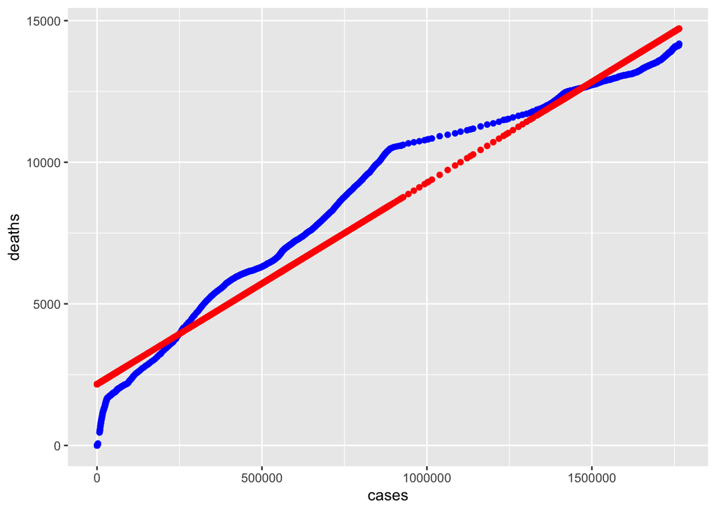

```r
colo_w_pred <- colo %>% mutate(pred = predict(mod))
colo_w_pred %>% ggplot() +
  geom_point(aes(x = cases, y = deaths), color = "blue") +
  geom_point(aes(x = cases, y = pred), color = "red")
```

There’s an incredibly strong relationship between cases and deaths.

### Additional Questions

How did vaccine distribution affect case numbers?

## Bias

COVID was pervasive, world-changing, and devasting. Some people were more affected than others. Those who were greatly affected, maybe lost a loved one, may attempt to extract more insight than there is. Whereas someone who was less affected may opt to take a more surface level approach.

### Bias Mitigation Techniques

A fundamental starting point is to engage in self-reflection to develop an understanding of personal biases. Approach the problem from a differing point of view, seeking a greater level of understanding and objectivity.